# AnalysisElements

Anabella Trigila

7/6/2020

# Load objects

```r
mammal_genes_ranked_path <- file.path(out_base_path,
                                "15_table_mammal_genes_ranked_by_ncMARs.txt")
mammal_genes_ranked <- read.table(mammal_genes_ranked_path)
#------
annotations_base_path <- file.path(data_base_path,
                                   "7. human chicken transcripts")
human_genes_file_path <- file.path(annotations_base_path,
                                   "knownCanonical(hg38).bed")
if(!file.exists(human_genes_file_path)) {
    annotations_file_path_zip <- file.path(annotations_base_path,
                                   "knownCanonical(hg38).zip")
    unzip(zipfile = annotations_file_path_zip,
          exdir = annotations_base_path)
}

human_genes <- read.table(human_genes_file_path)
human_genes <-human_genes  %>%
  dplyr::rename("chr" = "V1", "start" = "V2", "end" = "V3", "name" = "V4") %>%
  mutate(length = end-start)

#clean unzipped file
if(file.exists(human_genes_file_path)) {
    file.remove(human_genes_file_path)
}
```

```
## [1] TRUE
```

```r
#------

avian_genes_ranked_path <- file.path(out_base_path,
                                "15_table_avian_genes_ranked_by_ncAvARs.txt")
avian_genes_ranked <- read.table(avian_genes_ranked_path)

#------

annotations_base_path <- file.path(data_base_path,
                                   "7. human chicken transcripts")
avian_genes_file_path <- file.path(annotations_base_path,
                                   "galGal6_transcripts.bed")
if(!file.exists(avian_genes_file_path)) {
    annotations_file_path_zip <- file.path(annotations_base_path,
                                   "galGal6_transcripts.zip")
    unzip(zipfile = annotations_file_path_zip,
          exdir = annotations_base_path)

}

# Load chicken gene regions
avian_genes_df <- read.table(avian_genes_file_path)
#clean unzipped file
if(file.exists(avian_genes_file_path)) {
    file.remove(avian_genes_file_path)
}
```

```
## [1] TRUE
```

```r
avian_genes  <- avian_genes_df %>%
  dplyr::rename("chr" = "V1", "start" = "V2", "end" = "V3", "name" = "V4") %>%
  dplyr::mutate(length = end-start) %>%
  group_by(name) %>% filter(length == max(length)) %>%
  unique.data.frame()

avian_genes_granges <- makeGRangesFromDataFrame(avian_genes,
                                                keep.extra.columns=TRUE)
genome(avian_genes_granges) <- "galGal6"

#------
non_coding_acc_regions_mammals_ranked_path <- file.path(out_base_path,
                        "13_non_coding_acc_regions_mammals_ranked.bed")
non_coding_acc_regions_mammals_ranked_df <- read.table(
    non_coding_acc_regions_mammals_ranked_path)
non_coding_acc_regions_mammals_ranked <- makeGRangesFromDataFrame(
    non_coding_acc_regions_mammals_ranked_df, keep.extra.columns = TRUE)
#------
annotations_base_path <- file.path(data_base_path,
                                   "7. human chicken transcripts")

human_genes_file_path <- file.path(annotations_base_path,
                                   "knownCanonical(hg38).bed")
if(!file.exists(human_genes_file_path)) {
    annotations_file_path_zip <- file.path(annotations_base_path,
                                   "knownCanonical(hg38).zip")
    unzip(zipfile = annotations_file_path_zip,
          exdir = annotations_base_path)
}

human_genes <- read.table(human_genes_file_path) %>%
  dplyr::rename("chr" = "V1", "start" = "V2", "end" = "V3", "name" = "V4") %>%
  mutate(length = end-start)

#clean unzipped file
if(file.exists(human_genes_file_path)) {
    file.remove(human_genes_file_path)
}
```

```
## [1] TRUE
```

```r
human_genes_granges <- human_genes %>%
  makeGRangesFromDataFrame(keep.extra.columns=TRUE)
#------
non_coding_acc_regions_aves_ranked_path <-  file.path(out_base_path,
                                "14_non_coding_acc_regions_aves_ranked.bed")

non_coding_acc_regions_aves_ranked_df <- read.table(
    non_coding_acc_regions_aves_ranked_path)
non_coding_acc_regions_aves_ranked <- makeGRangesFromDataFrame(
    non_coding_acc_regions_aves_ranked_df, keep.extra.columns = TRUE)
#------

mammals_acc_non_coding_path <- file.path(out_base_path,
                                '6_mammals_accelerated_noncoding_elements.bed')
mammals_acc_non_coding_df <- read.table(mammals_acc_non_coding_path)

mammals_acc_non_coding <- makeGRangesFromDataFrame(mammals_acc_non_coding_df,
                                                   keep.extra.columns = TRUE)
genome(mammals_acc_non_coding) <- 'hg38'

#------

conserved_mammals_path <- file.path(out_base_path,
                                        "1_conserved_mammals_phastcons.bed")
conserved_mammals_df <- read.table(conserved_mammals_path)

conserved_mammals <- makeGRangesFromDataFrame(conserved_mammals_df,
                                              keep.extra.columns = TRUE)
genome(conserved_mammals) <- 'hg38'

#------

conserved_aves_path <- file.path(out_base_path,
                                 "2_conserved_aves_phastcons.bed")
conserved_aves_df <- read.table(conserved_aves_path)

conserved_aves <- makeGRangesFromDataFrame(conserved_aves_df,
                                              keep.extra.columns = TRUE)
genome(conserved_aves) <- 'galGal6'

#------

aves_acc_non_coding_path <- file.path(out_base_path,
                                    '8_aves_accelerated_noncoding_elements.bed')
aves_acc_non_coding_df <- read.table(aves_acc_non_coding_path)

aves_acc_non_coding <- makeGRangesFromDataFrame(aves_acc_non_coding_df,
                                                keep.extra.columns = TRUE)
genome(aves_acc_non_coding) <- "galGal6"
```

### Frequency of non-coding accelerated elements in intronic regions per transcriptional unit

Ranking the genes with the highest number of accelerated elements could be influencing the gene length. For this reason, we decided to plot the number of accelerated elements according to their gene size.

```r
# Table with number of ncMARs per human gene
table_mammals_perTU <- inner_join(mammal_genes_ranked, human_genes, by = 'name') %>%
  dplyr::select(name, number_of_ncMARs,length)

# Plot mammals results
plot_mammals_perTU <- plot_scatter(
  data = table_mammals_perTU,
  x_var = "length",
  y_var = "number_of_ncMARs",
  name_var = "name",
  x_label = "Gene length",
  y_label = "No. ncMARs",
  png_image =  NULL,
  number_to_show = 12
)

# Table with number of ncAvARs per chicken gene
table_aves_perTU <- inner_join(avian_genes_ranked, avian_genes, by = 'name') %>%
  dplyr::select(name, number_of_ncAvARs,length)


# Plot aves results
plot_aves_perTU <- plot_scatter(
  data = table_aves_perTU,
  x_var = "length",
  y_var = "number_of_ncAvARs",
  name_var = "name",
  x_label = "Gene length",
  y_label = "No. ncAvARs",
  png_image =  NULL,
  number_to_show = 10
)
```

Could this be a result of a high proportion of CNEs in each gene? Meaning: Genes with a higher proportion of phastCons have a higher proportion of accelerated elements?

```r
# Plot bargraphs
mammals_1 <- plot_horizontal_bar(head(mammal_genes_ranked, n = 20),
                    x_var = number_of_ncMARs,
                    y_var = name,
                    x_label = "ncMARs",
                    png_image = file.path(scripts_base_path, "mammal.png"))

aves_1 <- plot_horizontal_bar(head(avian_genes_ranked, n = 20),
                    x_var = number_of_ncAvARs,
                    y_var = name,
                    x_label = "ncAvARs",
                    png_image = file.path(scripts_base_path, "bird.png"))
# Plot scatters

cow_1 <- cowplot::plot_grid(mammals_1, aves_1,
                            labels = c('A', 'B'), label_size = 12,
                            align = "h", axis = "b")
cow_2 <- cowplot::plot_grid(plot_mammals_perTU,
                            plot_aves_perTU, labels = c('C', 'D'),
                            label_size = 12, align = "v",
                            axis = "l",  scale = 1)


# Write to outputs
cow_3 <- cowplot::plot_grid(cow_1, cow_2, ncol = 1, rel_heights = c(2, 1), align = "v")

plot_out_path <- file.path(out_base_path, "16_plot_genes_ranked_by_acc_elements.pdf")
ggplot2::ggsave(cow_3, filename = plot_out_path,
                width = 8, height = 11, units = "in")
```

### Distribution of accelerated sequences in topologically associated domains (TADs)

```r
# Load list of TADs
mammal_TADs_file_path <- file.path(data_base_path ,"8. TADs",
                                   "CP_TADs_hg38.bed")
mammal_TADs <- read.table(mammal_TADs_file_path) %>%
  dplyr::rename(chr = "V1" , start = "V2", end =  "V3") %>%
  mutate(name = paste0(chr,":",start,"-",end)) %>%
  makeGRangesFromDataFrame(keep.extra.columns=TRUE)

# Intersection of Non-Coding MAMMAL accelerated functional elements with MAMMAL TADs
TADs_with_ncMARs <- findOverlaps(mammal_TADs,
                                non_coding_acc_regions_mammals_ranked)

# Ranking of TADs with highest ncMARs
mammal_TADs_ranked <- as.data.frame(mammal_TADs[queryHits(TADs_with_ncMARs),]) %>%
    group_by(name) %>%
    summarize(number_of_ncMARs =  n()) %>%
    arrange(desc(number_of_ncMARs))

# Rename Table
mammal_TADs_ranked <-  mammal_TADs_ranked %>%
  dplyr::rename("Number of ncMARs" = "number_of_ncMARs") %>%
  dplyr::rename("TAD Region coordinates" = "name")

# Create table to display

main.title <- "Table 2"

table_tads_ranked_mammals <- ggpubr::ggtexttable(head(mammal_TADs_ranked, n = 5),
    rows = NULL, theme = ggpubr::ttheme("blank")) %>%
    ggpubr::tab_add_hline(at.row = 1:2, row.side = "top", linewidth = 2) %>%
    ggpubr::tab_add_title(text = main.title, face = "bold")

# Write to outputs
table_tads_ranked_mammals_out_path <- file.path(out_base_path,
                            "17_table_TADs_ranked_by_acc_elements_mammals.pdf")
ggplot2::ggsave(table_tads_ranked_mammals,
                filename = table_tads_ranked_mammals_out_path)
# Which genes are there inside and closest to the top TADs?

top_TADs_mammals <- mammal_TADs[mcols(mammal_TADs)$name %in%
                    head(mammal_TADs_ranked$`TAD Region coordinates`, n = 5)]

find_genes_in_TADs <- function(tads, genes) {

    result <- data.frame(TAD_Coordinates = character(),
                       Inside_Genes = character(),
                       Closest_Genes = character(),
                       stringsAsFactors = FALSE)

  for (i in seq_along(tads)) {

    tad <- tads[i]
    inside_genes <- genes[overlapsAny(genes, tad)]

    left_gene <- genes[precede(tad, genes)]
    right_gene <- genes[follow(tad, genes)]

    inside_names <- ifelse(length(inside_genes) > 0,
                           paste(mcols(inside_genes)$name,
                                 collapse = ", "), "None")
    left_name <- ifelse(length(left_gene) > 0, mcols(left_gene)$name, "None")
    right_name <- ifelse(length(right_gene) > 0, mcols(right_gene)$name, "None")

    closest_names <- paste(left_name, right_name, sep = ", ")

    result <- rbind(result, data.frame(TAD_Coordinates = tad$name,
                                       Inside_Genes = inside_names,
                                       Closest_Genes = closest_names,
                                       stringsAsFactors = FALSE))
  }

  return(result)
}

# Find genes for the TADs
top_TADs_mammals_and_genes <- find_genes_in_TADs(top_TADs_mammals,
                                                 human_genes_granges)

# Write table to outputs
top_TADs_mammals_and_genes_out_path <- file.path(out_base_path,
                                "17_table_hg38_genes_in_ncMARs_TADs.txt")
write.table(top_TADs_mammals_and_genes,
            file = top_TADs_mammals_and_genes_out_path)
```

```r
# Load list of TADs

chicken_TADs_file_path <- file.path(data_base_path, "8. TADs",
                                    "Fibroblast_TADs_galGal6.bed")

chicken_TADs <- read.table(chicken_TADs_file_path) %>%
  dplyr::rename(chr = "V1" , start = "V2", end =  "V3") %>%
  mutate(name = paste0(chr,":",start,"-",end)) %>%
  makeGRangesFromDataFrame(keep.extra.columns=TRUE)
genome(chicken_TADs) <- "galGal6"

# Intersection of Non-Coding Avian accelerated functional elements with Chicken Genes
TADs_with_ncAvARs <- findOverlaps(chicken_TADs,
                                  non_coding_acc_regions_aves_ranked)

# Ranking of TADs with highest ncAvARs
avian_TADs_ranked <- as.data.frame(
    chicken_TADs[queryHits(TADs_with_ncAvARs),]) %>%
    group_by(name) %>%
    summarize(number_of_ncAvARs =  n()) %>%
    arrange(desc(number_of_ncAvARs))

# Rename Table
avian_TADs_ranked <-  avian_TADs_ranked %>%
    dplyr::rename("Number of ncAvARs" = "number_of_ncAvARs") %>%
    dplyr::rename("TAD Region coordinates" = "name")

# Create table to display
main.title <- "Table 3"

table_tads_ranked_aves <- ggpubr::ggtexttable(
    head(avian_TADs_ranked, n = 5),
    rows = NULL,
    theme = ggpubr::ttheme("blank")) %>%
 ggpubr::tab_add_hline(at.row = 1:2, row.side = "top", linewidth = 2) %>%
 ggpubr::tab_add_title(text = main.title, face = "bold")

# Write to outputs
table_tads_ranked_aves_out_path <- file.path(out_base_path,
                            "18_table_TADs_ranked_by_acc_elements_aves.pdf")
ggplot2::ggsave(table_tads_ranked_aves,
                filename = table_tads_ranked_aves_out_path)
# Which genes are there inside and closest to the top TADs? (Reviewer 2, P10)
top_TADs_chicken <- chicken_TADs[mcols(chicken_TADs)$name %in%
                        head(avian_TADs_ranked$`TAD Region coordinates`, n = 5)]

# Find genes for the TADs

top_TADs_avian_and_genes <- find_genes_in_TADs(top_TADs_chicken,
                                               avian_genes_granges)

# Write table to outputs
top_TADs_avian_and_genes_out_path <- file.path(out_base_path,
                                "18_table_galGal6_genes_in_ncAvARs_TADs.txt")
write.table(top_TADs_avian_and_genes, file = top_TADs_avian_and_genes_out_path)
```

# Common non-coding regions

We were interested in exploring whether there was acceleration in orthologous non-coding regions of birds and mammals. This could indicate that certain amniote conserved non-coding elements in the genome had a function that was relevant for both lineages. To do this, we liftedOver the genomic coordinates from the avian accelerated elements into the hg38 genome.

```r
library(rtracklayer)

annotations_base_path <- file.path(data_base_path, "9. liftover")
chain_file_path <- file.path(annotations_base_path, "galGal6ToHg38.over.chain")
if(! file.exists(chain_file_path)) {
    chain_file_path_zip <- file.path(annotations_base_path, "galGal6ToHg38.over.zip")
    unzip(chain_file_path_zip, exdir = annotations_base_path)
}

# liftOver galGal6 coordinates to hg38 coordinates
# path <- here::here("data", "9. liftover", "galGal6ToHg38.over.chain")
ch <- import.chain(chain_file_path)
if(file.exists(chain_file_path)) {
    file.remove(chain_file_path)
}
```

```
## [1] TRUE
```

```r
genome(non_coding_acc_regions_aves_ranked) = "galGal6"

seqlevelsStyle(non_coding_acc_regions_aves_ranked) = "UCSC"  # necessary
non_coding_acc_regions_aves_ranked_hg38 = liftOver(non_coding_acc_regions_aves_ranked, ch)

non_coding_acc_regions_aves_ranked_hg38_unlist <- non_coding_acc_regions_aves_ranked_hg38 %>%
  unlist() %>%
  reduce(min.gapwidth = 10L)
```

We originally have 2888 non-coding accelerated regions in aves. We lift-over those regions to the hg38 genome in order to make the overlaps with mammals. In the lift-over, we have 2304 successfully mapped elements regions.

```r
# Find overlapping elements between the two sets of genomic regions
common_non_coding_regions_overlap <- findOverlaps(non_coding_acc_regions_mammals_ranked,
                                                  non_coding_acc_regions_aves_ranked_hg38)

common_non_coding_regions <- non_coding_acc_regions_mammals_ranked[
  queryHits(common_non_coding_regions_overlap),] %>%
  unique()

# Write to outputs (Supp. Table S6)
common_non_coding_regions_out_path <- file.path(out_base_path,
                                "23_common_non_coding_regions_hg38.bed")
write.table(common_non_coding_regions,
            file = common_non_coding_regions_out_path)
```

We intersected the accelerated regions of mammals and birds, which led to 285 non-coding common regions (CommonAcc).

The genes with the highest number of regulatory regions are those in the following table.

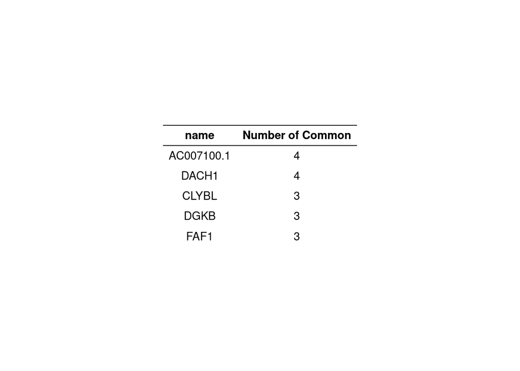

```r
# Intersection of Non-Coding Mammal accelerated functional elements with Human Genes
common_non_coding_gene_overlap <- findOverlaps(human_genes_granges,
                                               common_non_coding_regions)

common_non_coding_genes_ranked <- as.data.frame(
    human_genes_granges[queryHits(common_non_coding_gene_overlap),]) %>%
    group_by(name) %>%
    summarize(`Number of Common` =  n()) %>%
    arrange(desc(`Number of Common`)) # %>%
    # rename("Gene" = "name")

ggpubr::ggtexttable(head(common_non_coding_genes_ranked, n = 5),
                    rows = NULL,
                    theme = ggpubr::ttheme("blank")) %>%
                    ggpubr::tab_add_hline(at.row = 1:2,
                                          row.side = "top",
                                          linewidth = 2)
```

# Clusters of non-coding modification in the genome

```r
# Calculate elements in the same fashion as Holloway et al. 2016
non_coding_acc_regions_mammals_ranked$cluster <-
    subjectHits(findOverlaps(non_coding_acc_regions_mammals_ranked,
                             reduce(non_coding_acc_regions_mammals_ranked,
                                    min.gapwidth = 50000L))) # Adds a new column to all accelerated elements classyfing each of them to a cluster

# Dataframe with ncMARs in clusters
df_mammal <- data.frame(
  name = non_coding_acc_regions_mammals_ranked$element_accelerated_ranking_name,
  cluster = non_coding_acc_regions_mammals_ranked$cluster,
  chr = as.character(non_coding_acc_regions_mammals_ranked@seqnames),
  start = as.character(non_coding_acc_regions_mammals_ranked@ranges@start),
  end = as.character(non_coding_acc_regions_mammals_ranked@ranges@start + non_coding_acc_regions_mammals_ranked@ranges@width)) %>%
  group_by(cluster) %>%
  mutate(freq = n()) %>%
  arrange(desc(freq), cluster) %>%
  filter(freq > 3)

# Export table to outputs
df_mammal_out_path <- file.path(out_base_path, "27_non_coding_ncMARs_clusters.txt")
write.table(df_mammal, file = df_mammal_out_path)
```

There are 801 ncMARs in 145 clusters.

We also calculate which ncAvARs elements are also distributed in clusters by applying the same methodology as previously.

```r
# Calculate elements in the same fashion as Holloway et al. 2016
non_coding_acc_regions_aves_ranked$cluster <- subjectHits(findOverlaps(
  non_coding_acc_regions_aves_ranked,
  reduce(non_coding_acc_regions_aves_ranked,
         min.gapwidth = 50000L)))

# Dataframe with ncAvARs in clusters
df_aves <-  data.frame(name = non_coding_acc_regions_aves_ranked$element_accelerated_ranking_name,
                       cluster = non_coding_acc_regions_aves_ranked$cluster,
                       chr = as.character(non_coding_acc_regions_aves_ranked@seqnames),
                       start = as.character(non_coding_acc_regions_aves_ranked@ranges@start),
                       end = as.character(non_coding_acc_regions_aves_ranked@ranges@start + non_coding_acc_regions_aves_ranked@ranges@width)) %>%
  group_by(cluster) %>%
  mutate(freq = n()) %>%
  arrange(desc(freq), cluster) %>%
  filter(freq > 3)

# Export table to outputs
df_aves_out_path <- file.path(out_base_path, "29_non_coding_ncAvARs_clusters.txt")
write.table(df_aves, file = df_aves_out_path)
```

There are 962 ncAvARs in 150 clusters.

# Developmental and regulatory features of non-coding accelerated elements

LOLA “provides functions for testing overlap of sets of genomic regions with public and custom region set (genomic ranges) databases. This makes it possible to do automated enrichment analysis for genomic region sets, thus facilitating interpretation of functional genomics and epigenomics data.” I use the dataset LOLA core to test for enrichment: http://big.databio.org/regiondb/LOLACoreCaches_180412.tgz

```r
### Aves LOLA analysis ###

# Load chicken expression regions in LOLA
regionDB_galgal6 <- loadRegionDB(file.path(data_base_path,
                                           "10. lola", "galGal6"))
```

```
## Reading collection annotations:
```

[output not shown]

[output not shown]

```
## Reading region annotations...
```

[output not shown]

[output not shown]

```
## chicken_FAANG_state
```

[output not shown]

```
## chicken_FAANG_TSR
```

[output not shown]

```r
# Run LOLA (acc elements non_coding vs. conserved aves elements)
locResults_aves_galgal6 <- runLOLA(aves_acc_non_coding,
                           conserved_aves,
                           regionDB_galgal6,
                           cores=4)
```

```
## Converting GRanges to GRangesList.
```

```
## Calculating unit set overlaps...
```

```
## Calculating universe set overlaps...
```

```
## Calculating Fisher scores...
```

```r
# Sort results by pvalue
lola.output_aves_galgal6 <- locResults_aves_galgal6[order(pValueLog,
                                                          decreasing=TRUE),]

# Sort results by maxRank
lola.output_aves_galgal6 <- locResults_aves_galgal6[order(maxRnk,
                                                          decreasing=FALSE),]


lola_plot_aves <- plot_lola(lola.output_aves_galgal6,
          value_col = "pValueLog",
          img_path = file.path(scripts_base_path, "bird.png"))
```